# Xu_Jingwen_AssignmentV

GitHub and the ticketmaster.com API

submitted by Jingwen Xu (Student ID: 5631584)

February 13 2021

I discussed together with Martin Scheerer (ID: 5631373), Michael Lyubkin (ID: 4168485), Lana Kern (ID: 5395819), Anton Höhl (ID: 5637078) and Simon Metzger (ID: 5635087). I assure that my assignment conform to the rules and guidelines in the *Code of Conduct*.

## General Set-up

First of all, I clear the workspace and install the packages that be needed and load the packages.

```r
rm(list = ls())  # clear the workspace

# check if the packages has been installed; if not, then install
if (!require("tidyverse")) install.packages("tidyverse")
if (!require("xml2")) install.packages("xml2")
if (!require("httr")) install.packages("httr")
if (!require("jsonlite")) install.packages("jsonlite")
if (!require("rlist")) install.packages("rlist")
if (!require("ggplot2")) install.packages("ggplot2")

# load packages
library(tidyverse)
library(xml2)
library(httr)
library(jsonlite)
library(rlist)
library(ggplot2)
```

## Exercise 1: Setting up a new GitHub repository

The hyperlink is https://github.com/NeverJW/AssignmentV-DSPM.git

## Exercise 2: Getting to know the API

I visit the documentation website for the API provided by ticketmaster.com and familize myself with the features and functionalities of the Ticketmaster Discovery API. I have a particular look the rate limits. I use the API Explorer and will treat the key as secret.

## Exercise 3: Interacting with the API - the basics

### Search for event venues in Germany

```r
# source the API_key in another script, treat the API_key as secret
source("API_key.R")

# perform a first GET request to searches for event venues in Germany
res_venues <-
  GET(
    "https://app.ticketmaster.com/discovery/v2/venues?",
    query = list(
      apikey = API_key,
      locale = "*",
      countryCode   = "DE"
    )
  )

status_code(res_venues) # 200, a successful request
```

```
## [1] 200
```

```r
# extract the content from the response object
content <- fromJSON(content(res_venues, as = "text"))
```

According to the content from the response object, we have three main parts: `_embedded`, `_links` and `page`. In the `_embedded`, all features of venues are stored. It contains 20 rows and 19 columns (some columns contain more than one variable). In the `_links`, we can see the urls of different results. In the `page`, we can see the total elements and total pages, the number of current page and the size of current page. In this content, the total elements are 12238 and total pages are 612 if we have size=20. We are now in the 0 page and this page has 20 elements.

### Extract the 7 columns and 20 rows data frame

```r
# extract the 20 rows data frame
venue_data <- as.data.frame(content[["_embedded"]][["venues"]])
venue_data <-
  venue_data[c("name", "city", "postalCode", "address", "url", "location")]

# extract the 7 columns and 20 rows data frame
venue_data <-
  venue_data %>% mutate(
    city = city$name,
    address = address$line1,
    longitude = location$longitude,
    latitude = location$latitude,
    location = NULL
  )

# see the data frame whether it is same as in the assignment samples
glimpse(venue_data)
```

```
## Rows: 20
## Columns: 7
## $ name       <chr> "Gruenspan", "Philharmonie (Großer Saal)", "Beatpol", "M...
## $ city       <chr> "Hamburg", "Berlin", "Dresden", "Ludwigsburg", "Berlin",...
## $ postalCode <chr> "22767", "10785", "01157", "71638", "12435", "79108", "7...
## $ address    <chr> "Grosse Freiheit 58", "Herbert-von-Karajan-Straße 1", "A...
## $ url        <chr> "http://www.ticketmaster.de/venue/287155", "https://www....
## $ longitude  <chr> "9.958075", "13.36896", "13.67471", "9.1824", "13.42054"...
## $ latitude   <chr> "53.551885", "52.51007", "51.06498", "48.89121", "52.499...
```

## Exercise 4: Interacting with the API - advanced

```r
# total results
n <- as.numeric(content[["page"]][["totalElements"]])

# Number of complete pages, I want to extract 500 size per request
pages <- floor(n / 500) - 1 # because the page start from 0

# Number of entries on the last incomplete page:
remainder <- n - 500 * floor(n / 500)

# create a empty dataframe
# We initiate a dataframe in the correct dimensions to speed up our loop:
venue_df <- tibble(
  name  = character(n),
  city = character(n),
  postalCode = character(n),
  address   = character(n),
  url = character(n),
  longitude = character(n),
  latitude = character(n)
)

# write a loop that iterates throgh the results pages and perform a GET request for all venues in Germany
for (i in 0:pages) {
  res_venues <-
    GET(
      "https://app.ticketmaster.com/discovery/v2/venues?",
      query = list(
        apikey = API_key,
        locale = "*",
        size = "500",
        countryCode   = "DE",
        page   = i
      )
    )


  # extract the content as before
  content <- fromJSON(content(res_venues, as = "text"))

  # we gradually fill our data frame page by page (lines 1-500 in the first iteration, lines 501-1000 in the second iteration and so on)
  venue_df[(500 * (i + 1) - 499):(500 * (i + 1)), c(1, 3, 5)] <-
    as.data.frame(content[["_embedded"]][["venues"]][c("name", "postalCode", "url")])

  venue_df[(500 * (i + 1) - 499):(500 * (i + 1)), 2] <-
    as.data.frame(content[["_embedded"]][["venues"]][["city"]][["name"]])

  venue_df[(500 * (i + 1) - 499):(500 * (i + 1)), 4] <-
    content[["_embedded"]][["venues"]][["address"]][["line1"]]

  # there are NA values in the longitude and latitude, the longitude and latitude from lists without location will be set to NA in our data frame
  if (is.null(content[["_embedded"]][["venues"]][["location"]][["longitude"]]) == TRUE) {
    venue_df[(500 * (i + 1) - 499):(500 * (i + 1)), 6] <- NA
  } else {
    venue_df[(500 * (i + 1) - 499):(500 * (i + 1)), 6] <-
      content[["_embedded"]][["venues"]][["location"]][["longitude"]]
  }

  if (is.null(content[["_embedded"]][["venues"]][["location"]][["latitude"]]) == TRUE) {
    venue_df[(500 * (i + 1) - 499):(500 * (i + 1)), 7] <- NA
  } else {
    venue_df[(500 * (i + 1) - 499):(500 * (i + 1)), 7] <-
      content[["_embedded"]][["venues"]][["location"]][["latitude"]]
  }

  # ensure we will not vialate the rate limit (5 request per second) in this API
  Sys.sleep(0.2)
}

# the last page is incomplete, hence we add it manually outside the loop, as in this particular case, the loop would cause problems otherwise:
i <- i + 1

# get the elements of last page
res_venues <-
  GET(
    "https://app.ticketmaster.com/discovery/v2/venues?",
    query = list(
      apikey = API_key,
      locale = "*",
      size = "500",
      countryCode   = "DE",
      page   = i
    )
  )

content <- fromJSON(content(res_venues, as = "text"))


# same iteration as before
venue_df[(500 * (i + 1) - 499):(n), c(1, 3, 5)] <-
  as.data.frame(content[["_embedded"]][["venues"]][c("name", "postalCode", "url")])
venue_df[(500 * (i + 1) - 499):(n), 2] <-
  as.data.frame(content[["_embedded"]][["venues"]][["city"]][["name"]])
venue_df[(500 * (i + 1) - 499):(n), 4] <-
  content[["_embedded"]][["venues"]][["address"]][["line1"]]

# there are NA values in the longitude and latitude, the longitude and latitude from lists without location will be set to NA in our data frame
if (is.null(content[["_embedded"]][["venues"]][["location"]][["longitude"]]) == TRUE) {
  venue_df[(500 * (i + 1) - 499):(n), 6] <- NA
} else {
  venue_df[(500 * (i + 1) - 499):(n), 6] <-
    content[["_embedded"]][["venues"]][["location"]][["longitude"]]
}

if (is.null(content[["_embedded"]][["venues"]][["location"]][["latitude"]]) == TRUE) {
  venue_df[(500 * (i + 1) - 499):(n), 7] <- NA
} else {
  venue_df[(500 * (i + 1) - 499):(n), 7] <-
    content[["_embedded"]][["venues"]][["location"]][["latitude"]]
}

# see the whole data frame
glimpse(venue_df)
```

```
## Rows: 12,238
## Columns: 7
## $ name       <chr> "Gruenspan", "Philharmonie (Großer Saal)", "Beatpol", "M...
## $ city       <chr> "Hamburg", "Berlin", "Dresden", "Ludwigsburg", "Berlin",...
## $ postalCode <chr> "22767", "10785", "01157", "71638", "12435", "79108", "7...
## $ address    <chr> "Grosse Freiheit 58", "Herbert-von-Karajan-Straße 1", "A...
## $ url        <chr> "http://www.ticketmaster.de/venue/287155", "https://www....
## $ longitude  <chr> "9.958075", "13.36896", "13.67471", "9.1824", "13.42054"...
## $ latitude   <chr> "53.551885", "52.51007", "51.06498", "48.89121", "52.499...
```

## Exercise 5: Visualizing the extracted data

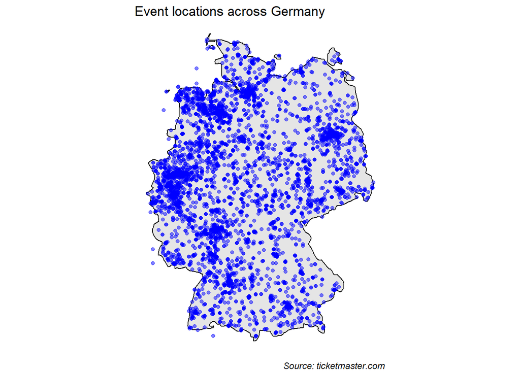

```r
# set NA where the value of longitude and latitude outside the border range
venue_df_map <- venue_df

venue_df_map$longitude <- as.numeric(venue_df_map$longitude)
venue_df_map$latitude <- as.numeric(venue_df_map$latitude)

venue_df_map$longitude[venue_df_map$longitude < 5.866944] <- NA
venue_df_map$longitude[venue_df_map$longitude > 15.043611] <- NA

venue_df_map$latitude[venue_df_map$latitude < 47.271679] <- NA
venue_df_map$latitude[venue_df_map$latitude > 55.0846] <- NA

# plot the map with points which indicate the locations of event venues across Germany
ggplot(venue_df_map, aes(x = as.numeric(longitude), y = as.numeric(latitude))) +
  geom_polygon(
    aes(x = long, y = lat, group = group),
    data = map_data("world", region = "Germany"),
    fill = "grey90",
    color = "black"
  ) + geom_point(color = "blue",
                 na.rm = TRUE,
                 alpha = 0.5) +
  theme_void() + coord_quickmap() +
  labs(title = "Event locations across Germany", caption = "Source: ticketmaster.com") +
  theme(
    title = element_text(size = 8, face = 'bold') +
      coord_cartesian(
        xlim = c(5.866944 - .2, 15.043611 + .2),
        ylim = c(47.271679 - .2, 55.0846 + .2)
      ),
    plot.caption = element_text(face = "italic")
  )
```